# bssm: Bayesian Inference of Non-linear and Non-Gaussian State Space Models in R

## Markov chain Monte Carlo in *bssm*

The main purpose of the *bssm* is to allow computationally efficient MCMC-based inference for various state space models. For this task, a method `run_mcmc` can be used. The function takes several arguments, depending on the model class, but for many of these, default values are provided. For linear-Gaussian models, we only need to supply the number of iterations. Using the previously created local linear trend model for the New Haven temperature data of Section 4.1, we run an MCMC with 100,000 iterations where the first 10,000 is discarded as a burn-in (burn-in phase is also used for the adaptation of the proposal distribution):

```r
mcmc_bsm <- run_mcmc(bsm_model, iter = 1e5, burnin = 1e4)
```

The `print` method for the output of the MCMC algorithms gives a summary of the results, and detailed summaries for $\theta$ and $\alpha$ can be obtained using `summary` function. For all MCMC algorithms, *bssm* uses so-called jump chain representation of the Markov chain $X_1,\ldots,X_n$, where we only store each accepted $X_k$ and the number of steps we stayed on the same state. So for example if $X_{1:n} = (1,2,2,1,1,1)$, we present such chain as $\tilde X = (1,2,1)$, $N=(1,2,3)$. This approach reduces the storage space and makes it more computationally efficient to use importance sampling type correction algorithms. One drawback of this approach is that the results from the MCMC run correspond to weighted samples from the target posterior, so some of the commonly used postprocessing tools need to be adjusted. Of course, in the case of other methods than IS-weighting, the simplest option is to just expand the samples to a typical Markov chain using the stored counts $N$. This can be done using the function `expand_sample`, which returns an object of class `"mcmc"` of the [*coda*](https://CRAN.R-project.org/package=coda) package (Plummer et al. 2006) (thus the plotting and diagnostic methods of *coda* can also be used). We can also directly transform the posterior samples to a `"data.frame"` object by using `as.data.frame` method for the MCMC output (for IS-weighting, the returned data frame contains additional column `weights`). This is useful, for example, for visualization purposes with the [*ggplot2*](https://CRAN.R-project.org/package=ggplot2) (Wickham 2016) package:

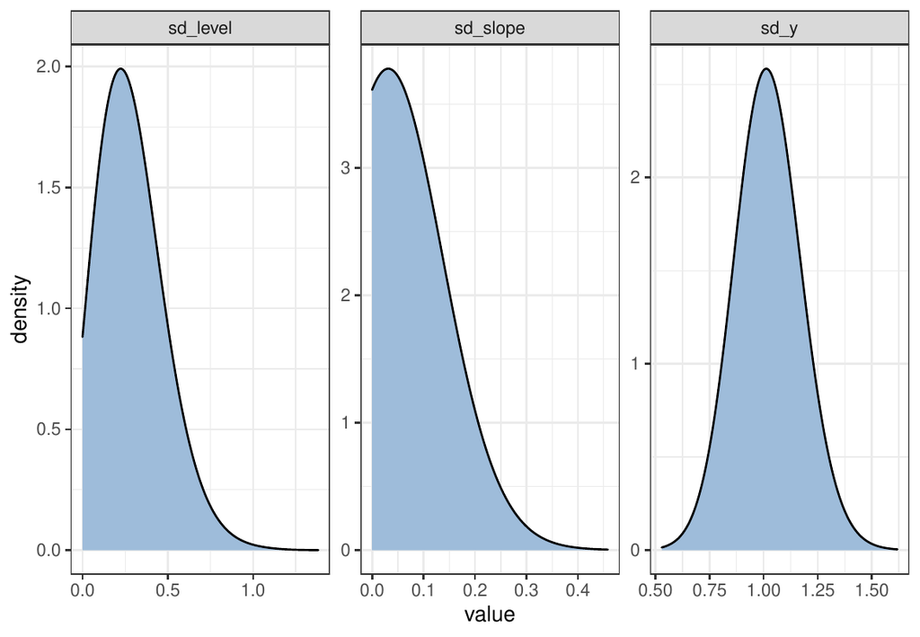

Figure 1: Posterior densities of hyperparameters $\theta$ of the linear-Gaussian model for nhtemp data.

```r
library("ggplot2")
d <- as.data.frame(mcmc_bsm, variable = "theta")
ggplot(d, aes(x = value)) +
  geom_density(bw = 0.1, fill = "#9ebcda") +
  facet_wrap(~ variable, scales = "free") +
  theme_bw()
```

Figure 1 shows the estimated posterior densities of the three standard deviation parameters of the model. The relatively large observational level standard deviation $\sigma_y$ suggests that the underlying latent temperature series is much smoother than the observed series, which can also be seen from Figure 2, which shows the original observations (black dots) spread around the estimated temperature series (solid line). This figure was drawn using [*dplyr*](https://CRAN.R-project.org/package=dplyr) (Wickham et al. 2021) and *ggplot2* with the following code:

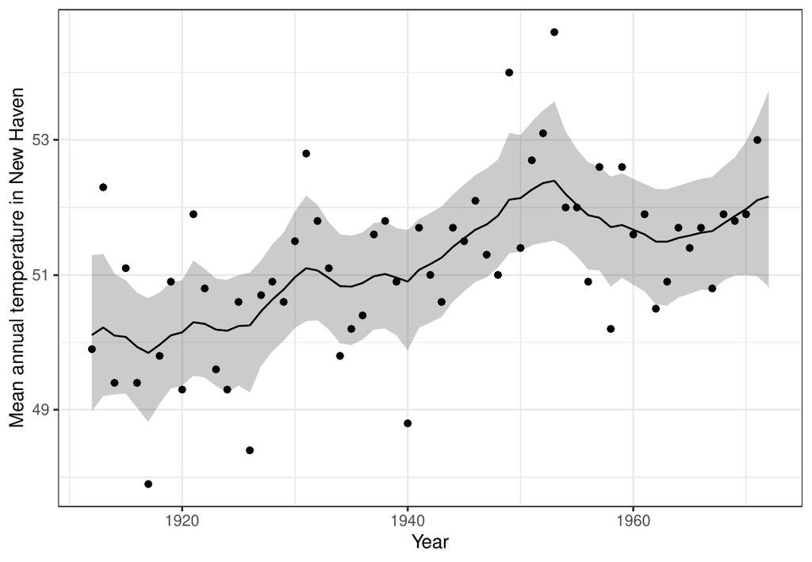

Figure 2: Observed annual average temperatures in New Haven (black dots) and predicted mean (solid line) with 95% prediction intervals (grey ribbon) from *bssm*.

```r
library("dplyr")
d <- as.data.frame(mcmc_bsm, variable = "states")
summary_y <- d %>%
  filter(variable == "level") %>%
  group_by(time) %>%
  summarise(mean = mean(value),
    lwr = quantile(value, 0.025),
    upr = quantile(value, 0.975))

ggplot(summary_y, aes(x = time, y = mean)) +
  geom_ribbon(aes(ymin = lwr, ymax = upr), alpha = 0.25) +
  geom_line() +
  geom_point(data = data.frame(mean = nhtemp,
    time = time(nhtemp))) +
  theme_bw() + xlab("Year") +
  ylab("Mean annual temperature in New Haven")
```

For non-Gaussian models, the default MCMC algorithm is an approximate inference based on Laplace approximation combined with importance sampling post-correction. It is also possible to perform first approximate MCMC using the argument `mcmc_type = "approx"` and then perform the post-correction step using the results from the approximate MCMC. In doing so, we can also use the function `suggest_N` to find a suitable number of particles $N$ for $\psi$-APF in the spirit of Doucet et al. (2015):

```r
out_approx <- run_mcmc(mng_model, mcmc_type = "approx", iter = 50000)
est_N <- suggest_N(mng_model, out_approx)
out_exact <- post_correct(mng_model, out_approx, particles = est_N$N)
```

The function `suggest_N` computes the standard deviation of the logarithm of the post-correction weights (i.e., the random part of log-likelihood of $\psi$-APF) at the approximate MAP estimator of $\theta$ using a range of $N$ and returns a list with component `N` which is the smallest number of particles where the standard deviation was less than one. For small and moderate problems, typically, 10-20 particles are enough.

## Filtering and smoothing

The *bssm* package also offers separate methods for performing (approximate) state filtering and smoothing which may be useful in some custom settings.

For LGSSM, methods `kfilter` and `smoother` perform Kalman filtering and smoothing. For non-Gaussian models with linear-Gaussian dynamics, approximate filtering and smoothing estimates can be obtained by calls to `kfilter` and `smoother`. These functions first construct an approximating Gaussian model for which the Kalman filter/smoother is then applied. For non-linear models defined by `nlg_ssm` we can run approximate filtering using the extended Kalman filter with the function `ekf`, the unscented Kalman filter with the function `ukf`, or the iterated EKF by changing the argument `iekf_iter` of the `ekf` function. Function `ekf_smoother` can be used for smoothing based on EKF/IEKF.

For particle filtering, the *bssm* package supports a general bootstrap particle filter for all model classes of the *bssm* (function `bootstrap_filter`). For `"nlg_ssm"`, extended Kalman particle filtering (Van Der Merwe et al. 2001) is also supported (function `ekpf_filter`). For particle smoothing, function `particle_smoother` with the smoothing based on BSF is available for all models. In addition, $\psi$-APF (using argument `method = "psi"`) is available for all models except for `"ssm_sde"` class. Currently, only the filter-smoother approach (Kitagawa 1996) for particle smoothing is supported.

# Comparison of IS-MCMC and HMC

Vihola, Helske, and Franks (2020) compared the computational efficiency of delayed acceptance MCMC and importance sampling type MCMC approaches in various settings. Here we make a small experiment comparing the generic Hamiltonian Monte Carlo using the NUTS sampler (Hoffman and Gelman 2014) with *rstan* and IS-MCMC with *bssm*. Given that the *bssm* package is specialized for state space models whereas Stan is a general purpose tool suitable for a wider range of problems, it is to be expected that *bssm* performs better in terms of computational efficiency. The purpose of this comparison is to illustrate this fact, i.e., that there is still demand for specialized algorithms for various types of statistical models. For the complete code of the experiment, see supplementary materials.

For the IS approach, we use `ng_bsm` function for model building, with prior variances 100 and 0.01 for the initial states $\mu_1$ and $\nu_1$. For hyperparameters, we used a fairly uninformative half-Normal distribution with a standard deviation of 0.5 for $\sigma_\mu$ and 0.1 for $\sigma_\nu$. We then ran the IS-MCMC algorithm with `run_mcmc` using a burn-in phase of length 10,000 and ran 50,000 iterations after the burn-in, with 10 particles per SMC.

Table 1 shows the results. We see both methods produce identical results (within the Monte Carlo error), but while *rstan* produces similar Monte Carlo standard errors with a smaller amount of total iterations than *bssm*, the total computation time of *rstan* is almost 80 times higher than with *bssm* (58 minutes versus 45 seconds), which suggests that for these types of problems it is highly beneficial to take advantage of the known model structure and available approximations versus general Bayesian software such as Stan which makes no distinction between latent states $\alpha$ and hyperparameters $\theta$.

Table 1: Estimates of posterior mean, standard deviation and Monte Carlo standard error of the mean for hyperparameters $\theta$ and latent states for last time point for the example model.

[output not shown]

# Conclusions

State space models are a flexible tool for analyzing a variety of time series data. Here, we introduced the R package *bssm* for fully Bayesian state space modeling for a large class of models with several alternative MCMC sampling strategies. All computationally intensive parts of the package are implemented with C++ with parallel computation support for IS-MCMC making it an attractive option for many common models where relatively accurate Gaussian approximations are available.

Compared to early versions of the *bssm* package, the option to define R functions for model updating and prior evaluation has lowered the bar for analyzing custom models. The package is also written in a way that it is relatively easy to extend to new model types similar to current `bsm_lg` in the future. The *bssm* package could be expanded to allow other proposal adaptation schemes such as the adaptive Metropolis algorithm by Haario, Saksman, and Tamminen (2001), as well as support for multivariate SDE models and automatic differentiation for EKF-type algorithms.

# Acknowledgements

This work has been supported by the Academy of Finland research grants 284513, 312605, 315619, 311877, and 331817.

Andrieu, Christophe, Arnaud Doucet, and Roman Holenstein. 2010. “Particle Markov Chain Monte Carlo Methods.” *Journal of Royal Statistical Society B* 72 (3): 269–342.

Banterle, Marco, Clara Grazian, Anthony Lee, and Christian P. Robert. 2019. “Accelerating Metropolis-Hastings Algorithms by Delayed Acceptance.” *Foundations of Data Science* 1 (2): 103. https://doi.org/10.3934/fods.2019005.

Carpenter, Bob, Andrew Gelman, Matthew Hoffman, Daniel Lee, Ben Goodrich, Michael Betancourt, Marcus Brubaker, Jiqiang Guo, Peter Li, and Allen Riddell. 2017. “Stan: A Probabilistic Programming Language.” *Journal of Statistical Software* 76 (1): 1–32. https://doi.org/10.18637/jss.v076.i01.

Christen, J. Andrés, and Colin Fox. 2005. “Markov Chain Monte Carlo Using an Approximation.” *Journal of Computational and Graphical Statistics* 14 (4): 795–810. https://doi.org/10.1198/106186005X76983.

de Valpine, Perry, Daniel Turek, Christopher Paciorek, Cliff Anderson-Bergman, Duncan Temple Lang, and Ras Bodik. 2017. “Programming with Models: Writing Statistical Algorithms for General Model Structures with NIMBLE.” *Journal of Computational and Graphical Statistics* 26: 403–13. https://doi.org/10.1080/10618600.2016.1172487.

Doucet, A., M. K. Pitt, G. Deligiannidis, and R. Kohn. 2015. “Efficient implementation of Markov chain Monte Carlo when using an unbiased likelihood estimator.” *Biometrika* 102 (2): 295–313. https://doi.org/10.1093/biomet/asu075.

Durbin, J., and S. J. Koopman. 2000. “Time Series Analysis of Non-Gaussian Observations Based on State Space Models from Both Classical and Bayesian Perspectives.” *Journal of Royal Statistical Society B* 62: 3–56.

———. 2002. “A Simple and Efficient Simulation Smoother for State Space Time Series Analysis.” *Biometrika* 89: 603–15.

———. 2012. *Time Series Analysis by State Space Methods*. 2nd ed. New York: Oxford University Press.

Eddelbuettel, Dirk, and Romain François. 2011. “Rcpp: Seamless R and C++ Integration.” *Journal of Statistical Software* 40 (8): 1–18. https://doi.org/10.18637/jss.v040.i08.

Eddelbuettel, Dirk, and Conrad Sanderson. 2014. “RcppArmadillo: Accelerating R with High-Performance C++ Linear Algebra.” *Computational Statistics and Data Analysis* 71: 1054–63. http://doi.org/10.1016/j.csda.2013.02.005.

Franks, Jordan, and Matti Vihola. 2020. “Importance Sampling Correction Versus Standard Averages of Reversible MCMCs in Terms of the Asymptotic Variance.” *Stochastic Processes and Their Applications* 130 (10): 6157–83. http://www.sciencedirect.com/science/article/pii/S0304414919304053.

Funk, Sebastian, and Aaron A. King. 2020. “Choices and Trade-Offs in Inference with Infectious Disease Models.” *Epidemics* 30: 100383. https://doi.org/10.1016/j.epidem.2019.100383.

Gordon, Neil J., D. J. Salmond, and A. F. M. Smith. 1993. “Novel Approach to Nonlinear/Non-Gaussian Bayesian State Estimation.” *IEE Proceedings-F* 140 (2): 107–13.

Haario, Heikki, Eero Saksman, and Johanna Tamminen. 2001. “An Adaptive Metropolis Algorithm.” *Bernoulli* 7 (2): 223–42. https://doi.org/10.2307/3318737.

Harvey, A. C. 1989. *Forecasting, Structural Time Series Models and the Kalman Filter*. Cambridge University Press.

Helske, Jouni. 2016. *ramcmc: Robust Adaptive Metropolis Algorithm*. https://CRAN.R-project.org/package=ramcmc.

———. 2017. “KFAS: Exponential Family State Space Models in R.” *Journal of Statistical Software* 78 (10): 1–39. https://doi.org/10.18637/jss.v078.i10.

Helske, Satu, and Jouni Helske. 2019. “Mixture Hidden Markov Models for Sequence Data: The seqHMM Package in R.” *Journal of Statistical Software* 88 (3): 1–32. https://doi.org/10.18637/jss.v088.i03.

Hoffman, Matthew D, and Andrew Gelman. 2014. “The No-U-Turn Sampler: Adaptively Setting Path Lengths in Hamiltonian Monte Carlo.” *The Journal of Machine Learning Research* 15 (1): 1593–623.

Iacus, Stefano Maria. 2016. *Sde: Simulation and Inference for Stochastic Differential Equations*. https://CRAN.R-project.org/package=sde.

Jacob, Pierre E., and Sebastian Funk. 2020. *Rbi: Interface to LibBi*. https://CRAN.R-project.org/package=rbi.

Jazwinski, Andrew. 1970. *Stochastic Processes and Filtering Theory*. Academic Press.

King, Aaron A., Dao Nguyen, and Edward L. Ionides. 2016. “Statistical Inference for Partially Observed Markov Processes via the R Package pomp.” *Journal of Statistical Software* 69 (12): 1–43. https://doi.org/10.18637/jss.v069.i12.

Kitagawa, Genshiro. 1996. “Monte Carlo Filter and Smoother for Non-Gaussian Nonlinear State Space Models.” *Journal of Computational and Graphical Statistics* 5 (1): 1–25.

Lindgren, Finn, and Håvard Rue. 2015. “Bayesian Spatial Modelling with R-INLA.” *Journal of Statistical Software* 63 (19): 1–25. https://doi.org/10.18637/jss.v063.i19.

Michaud, N., P. de Valpine, D. Turek, C. J. Paciorek, and D. Nguyen. 2020. “Sequential Monte Carlo Methods in the Nimble R Package.” arxiv:1703.06206. arXiv preprint.

Murray, Lawrence. 2015. “Bayesian State-Space Modelling on High-Performance Hardware Using LibBi.” *Journal of Statistical Software, Articles* 67 (10): 1–36. https://doi.org/10.18637/jss.v067.i10.

NIMBLE Development Team. 2020. “nimbleSMC: Sequential Monte Carlo Methods for NIMBLE.” https://doi.org/10.5281/zenodo.1211190.

Petris, Giovanni, and Sonia Petrone. 2011. “State Space Models in r.” *Journal of Statistical Software* 41 (4): 1–25. https://doi.org/10.18637/jss.v041.i04.

Plummer, Martyn, Nicky Best, Kate Cowles, and Karen Vines. 2006. “CODA: Convergence Diagnosis and Output Analysis for MCMC.” *R News* 6 (1): 7–11. https://CRAN.R-project.org/doc/Rnews/.

Stan Development Team. 2020. “RStan: The R Interface to Stan.” http://mc-stan.org/.

Tusell, Fernando. 2011. “Kalman Filtering in R.” *Journal of Statistical Software* 39 (2): 1–27. https://doi.org/10.18637/jss.v039.i02.

Van Der Merwe, Rudolph, Arnaud Doucet, Nando De Freitas, and Eric A Wan. 2001. “The Unscented Particle Filter.” In *Advances in Neural Information Processing Systems*, 584–90.

Vihola, Matti. 2012. “Robust Adaptive Metropolis Algorithm with Coerced Acceptance Rate.” *Statistics and Computing* 22 (5): 997–1008. https://doi.org/10.1007/s11222-011-9269-5.

Vihola, Matti, Jouni Helske, and Jordan Franks. 2020. “Importance Sampling Type Estimators Based on Approximate Marginal MCMC.” *Scandinavian Journal of Statistics*. https://doi.org/10.1111/sjos.12492.

Wickham, Hadley. 2016. *Ggplot2: Elegant Graphics for Data Analysis*. Springer-Verlag New York. https://ggplot2.tidyverse.org.

Wickham, Hadley, Romain François, Lionel Henry, and Kirill Müller. 2021. *Dplyr: A Grammar of Data Manipulation*. https://CRAN.R-project.org/package=dplyr.

[^1]: https://cran.r-project.org/package=bssm/vignettes/psi_pf.html
[^2]: https://CRAN.R-project.org/package=bssm